# Pràctica 2: Com realitzar la neteja i l’anàlisi de dades?

Gerard Ramos Gambús i Oriol Caravaca Muller

2023-01-03

## Carrega

Carreguem el dataset, observem que s’ha carregat correctament amb 303 observacions i 14 variables.

```r
heart <- read.csv("heart.csv")

heart_numeric<-heart

heart$sex <- as.factor(heart$sex)
heart$cp <- as.factor(heart$cp)
heart$fbs <- as.factor(heart$fbs)
heart$restecg <- as.factor(heart$restecg)
heart$exng <- as.factor(heart$exng)
heart$slp <- as.factor(heart$slp)
heart$caa <- as.factor(heart$caa)
heart$thall <- as.factor(heart$thall)


str(heart)
```

```
## 'data.frame':    303 obs. of  14 variables:
##  $ age     : int  63 37 41 56 57 57 56 44 52 57 ...
##  $ sex     : Factor w/ 2 levels "0","1": 2 2 1 2 1 2 1 2 2 2 ...
##  $ cp      : Factor w/ 4 levels "0","1","2","3": 4 3 2 2 1 1 2 2 3 3 ...
##  $ trtbps  : int  145 130 130 120 120 140 140 120 172 150 ...
##  $ chol    : int  233 250 204 236 354 192 294 263 199 168 ...
##  $ fbs     : Factor w/ 2 levels "0","1": 2 1 1 1 1 1 1 1 2 1 ...
##  $ restecg : Factor w/ 3 levels "0","1","2": 1 2 1 2 2 2 1 2 2 2 ...
##  $ thalachh: int  150 187 172 178 163 148 153 173 162 174 ...
##  $ exng    : Factor w/ 2 levels "0","1": 1 1 1 1 2 1 1 1 1 1 ...
##  $ oldpeak : num  2.3 3.5 1.4 0.8 0.6 0.4 1.3 0 0.5 1.6 ...
##  $ slp     : Factor w/ 3 levels "0","1","2": 1 1 3 3 3 2 2 3 3 3 ...
##  $ caa     : Factor w/ 5 levels "0","1","2","3",..: 1 1 1 1 1 1 1 1 1 1 ...
##  $ thall   : Factor w/ 4 levels "0","1","2","3": 2 3 3 3 3 2 3 4 4 3 ...
##  $ output  : int  1 1 1 1 1 1 1 1 1 1 ...
```

La descripció del dataset es la següent:

- age: Edat de la persona
- sex: Gènere de la persona
- cp: Tipus de dolor toràcic

  ```
  1 = angina típica
  2 = angina atípica
  3 = dolor no anginós
  4 = asimptomàtic
  ```

- trtbps: Pressió arterial en repòs (en mm Hg)
- chol: Colestorol en mg/dl obtingut mitjançant el sensor IMC
- fbs: Sucre en sang en dejú > 120 mg/dl

  ```
  (1 = cert; 0 = fals)
  ```

- restecg: Resultats electrocardiogràfics en repòs

  ```
  0 = normal
  1 = tenir una anomalia de l'ona ST-T
  2 = mostra una hipertròfia ventricular esquerre probable o definitiva
  ```

- thalachh: Freqüència cardíaca màxima aconseguida
- exng: Angina induïda per l’exercici

  ```
  (1 = sí; 0 = no)
  ```

- oldpeak: Depressió del ST induïda per l’exercici en relació amb el repòs
- slp: El pendent del segment ST de l’exercici màxim

  ```
  0 = sense pendent
  1 = pla
  2 = pendent avall
  ```

- caa: Nombre de vasos principals (0-3)
- thall: Talassèmia

  ```
  0 = nul
  1 = defecte fixat
  2 = normal
  3 = defecte reversible
  ```

- output:Sortida

  ```
  0 = menys probabilitat d'atac cardíac
  1 = més probabilitat d'atac cardíac
  ```

## Exploració del dataset

Extraiem un resum del la distribució de les variables i en busquem valors nulls. No apareixen valors nulls en les dades.

```r
summary(heart)
```

```
##       age        sex     cp          trtbps           chol       fbs
##  Min.   :29.00   0: 96   0:143   Min.   : 94.0   Min.   :126.0   0:258
##  1st Qu.:47.50   1:207   1: 50   1st Qu.:120.0   1st Qu.:211.0   1: 45
##  Median :55.00           2: 87   Median :130.0   Median :240.0
##  Mean   :54.37           3: 23   Mean   :131.6   Mean   :246.3
##  3rd Qu.:61.00                   3rd Qu.:140.0   3rd Qu.:274.5
##  Max.   :77.00                   Max.   :200.0   Max.   :564.0
##  restecg    thalachh     exng       oldpeak     slp     caa     thall
##  0:147   Min.   : 71.0   0:204   Min.   :0.00   0: 21   0:175   0:  2
##  1:152   1st Qu.:133.5   1: 99   1st Qu.:0.00   1:140   1: 65   1: 18
##  2:  4   Median :153.0           Median :0.80   2:142   2: 38   2:166
##          Mean   :149.6           Mean   :1.04           3: 20   3:117
##          3rd Qu.:166.0           3rd Qu.:1.60           4:  5
##          Max.   :202.0           Max.   :6.20
##      output
##  Min.   :0.0000
##  1st Qu.:0.0000
##  Median :1.0000
##  Mean   :0.5446
##  3rd Qu.:1.0000
##  Max.   :1.0000
```

```r
colSums(is.na(heart))
```

```
##      age      sex       cp   trtbps     chol      fbs  restecg thalachh
##        0        0        0        0        0        0        0        0
##     exng  oldpeak      slp      caa    thall   output
##        0        0        0        0        0        0
```

```r
colSums(heart == " ")
```

```
##      age      sex       cp   trtbps     chol      fbs  restecg thalachh
##        0        0        0        0        0        0        0        0
##     exng  oldpeak      slp      caa    thall   output
##        0        0        0        0        0        0
```

## Visualització

Visualitzem la distribució de les variables, utilitzem diagrames de caixa per a les variables continues i diagrames de barres per a les variables categoriques.

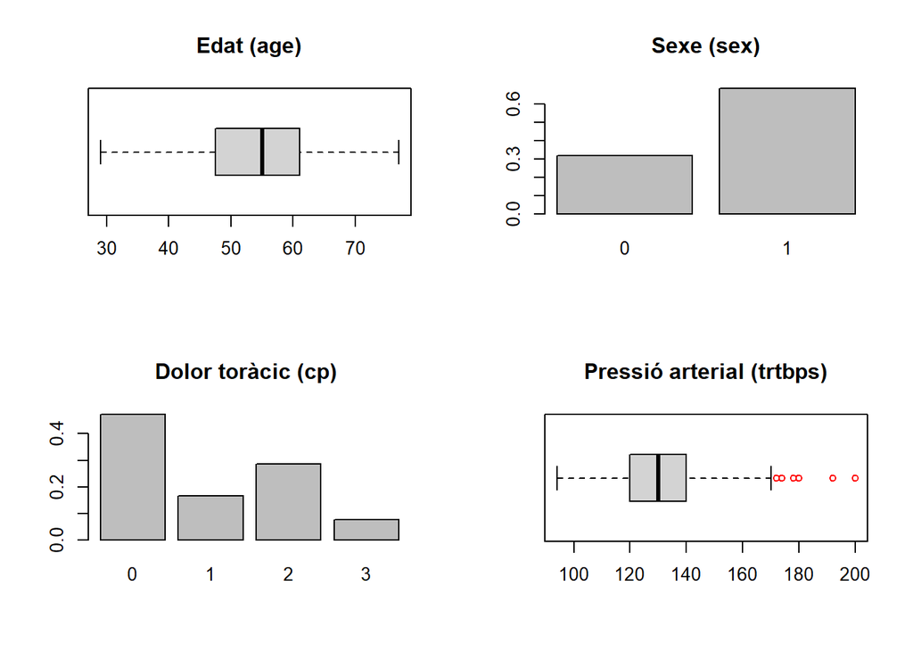

```r
par(mfrow=c(2,2))

boxplot(heart$age, horizontal=TRUE, main="Edat (age)" ,outcol="red")
barplot(prop.table(table(heart$sex)),main="Sexe (sex)")
barplot(prop.table(table(heart$cp)),main="Dolor toràcic (cp) ")
boxplot(heart$trtbps, horizontal=TRUE, main="Pressió arterial (trtbps)" ,outcol="red")
```

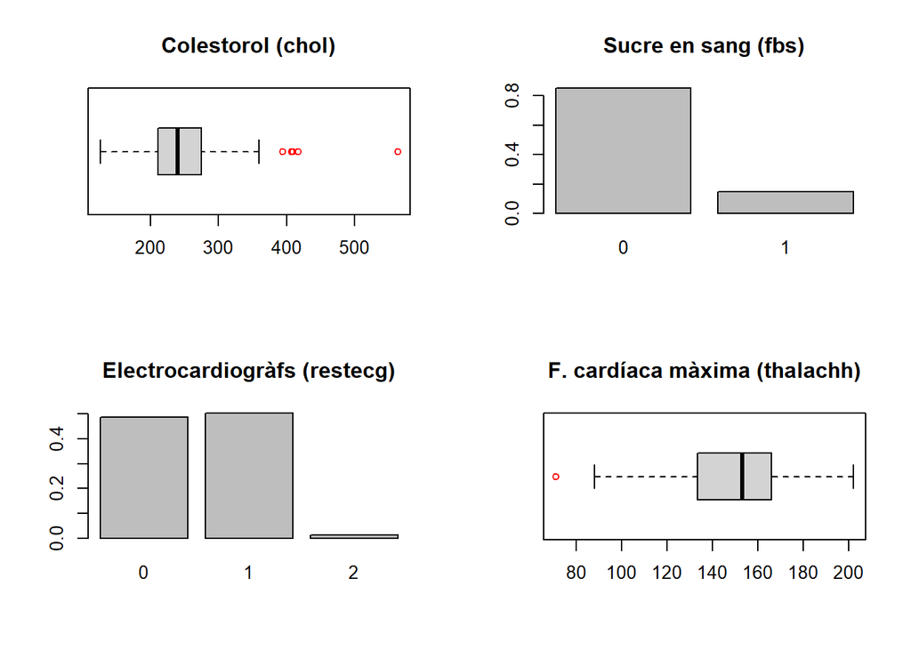

```r
boxplot(heart$chol, horizontal=TRUE, main="Colestorol (chol)",outcol="red")
barplot(prop.table(table(heart$fbs)),main="Sucre en sang (fbs)")
barplot(prop.table(table(heart$restecg)),main="Electrocardiogràfs (restecg)")
boxplot(heart$thalachh, horizontal=TRUE, main="F. cardíaca màxima (thalachh)",outcol="red")
```

[figure not shown]

```r
barplot(prop.table(table(heart$exng)),main="Angina induïda (exng)")
boxplot(heart$oldpeak, horizontal=TRUE, main="Depressió del ST (oldpeak)",outcol="red")
barplot(prop.table(table(heart$slp)),main="Pendent del ST (slp) ")
barplot(prop.table(table(heart$slp)), main="Nº Vasos (caa)")
```

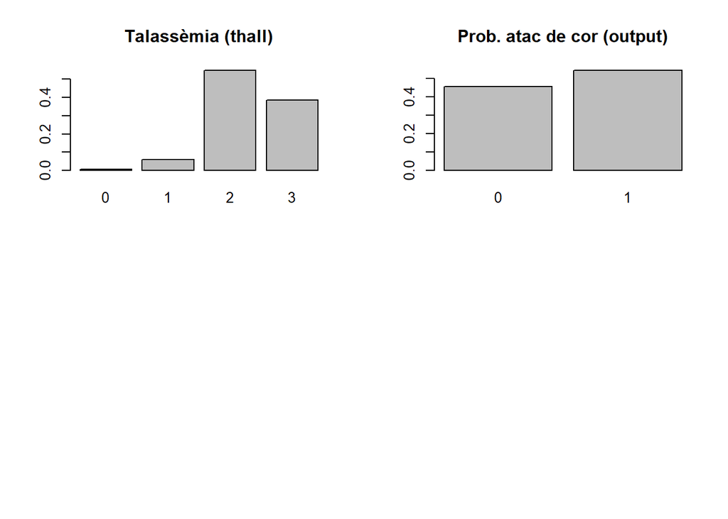

```r
barplot(prop.table(table(heart$thall)),main="Talassèmia (thall)")
barplot(prop.table(table(heart$output)),main="Prob. atac de cor (output)")
```

## Neteja de les dades

Tenint en compte la descipció, exploració i visualització del dataset, es determina que existeixen valors atipics, Aixì doncs es decideix fer una imputació de valors per eliminar la presencia d’aquest outliners.

Per el valor null que ens apareix a la variable categorica Talassèmia s’inputa el valor ‘normal’; per el valor 4 de la variable ‘caa’ s’imputa el valor 3; per a la resta d’oultiners de les variables continues s’utilitza l’algorimetme KNN per fer-ne l’imputació.

### Valors atípics

Eliminem els valor atipics.

```r
outliers_trtbps <- which(heart$trtbps %in% boxplot.stats(heart$trtbps)$out)
heart$trtbps[outliers_trtbps] <- NA
outliers_chol <- which(heart$chol %in% boxplot.stats(heart$chol)$out)
heart$chol[outliers_chol] <- NA
outliers_thalachh <- which(heart$thalachh %in% boxplot.stats(heart$thalachh)$out)
heart$thalachh[outliers_thalachh] <- NA
outliers_oldpeak <- which(heart$oldpeak %in% boxplot.stats(heart$oldpeak)$out)
heart$oldpeak[outliers_oldpeak] <- NA
```

### Imputació de valors

Imputem thall i caa.

```r
heart$thall[heart$thall ==0] <- 2
heart$caa[heart$caa ==4] <- 3
```

Imputem els outliners.

```r
columnesImputar<-colnames(heart)[colSums(is.na(heart)) > 0]
heart <-  kNN(heart, variable = columnesImputar, k = 5)
```

## Anàlisi de dades

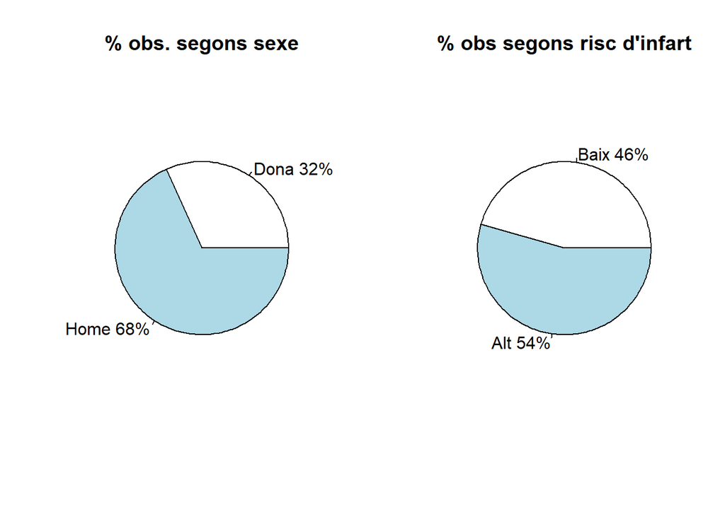

```r
par(mfrow=c(1,2))

props<-prop.table(table(heart$sex))
lbls <-  c("Dona", "Home")
pct <- round(props/sum(props)*100)
lbls <- paste(lbls, pct)
lbls <- paste(lbls,"%",sep="")
pie( props, labels = lbls , main = "% obs. segons sexe")

props<-prop.table(table(heart$output))
lbls <-  c("Baix", "Alt")
pct <- round(props/sum(props)*100)
lbls <- paste(lbls, pct)
lbls <- paste(lbls,"%",sep="")
pie( props, labels = lbls , main = "% obs segons risc d'infart")
```

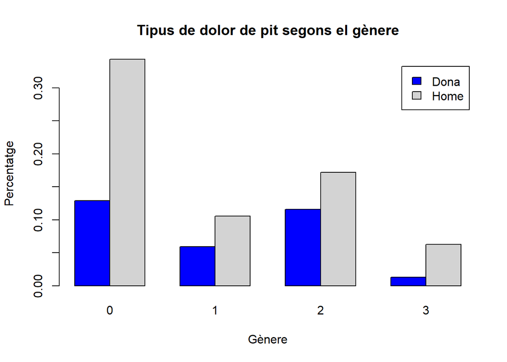

```r
counts <- table(heart$sex, heart$cp)
colors <- c("blue", "lightgrey")
barplot(prop.table(counts), beside = TRUE, col = colors,
        axes = TRUE,
        xlab = "Gènere",
        ylab = "Percentatge",
        main = "Tipus de dolor de pit segons el gènere",
        legend = c("Dona", "Home"))
```

Atenent al gràfic, els homes tenen bastantes mes angines típiques que les dones.

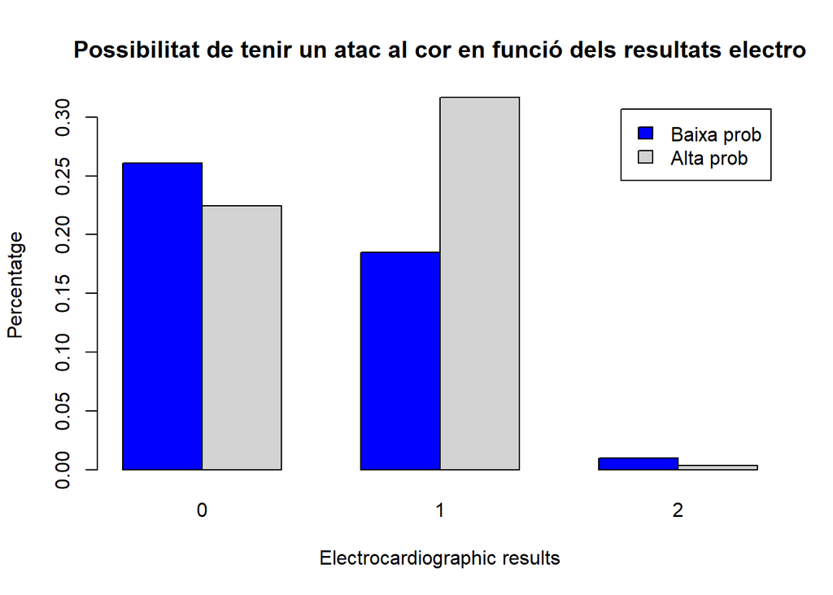

```r
counts <- table(heart$output, heart$restecg)
colors <- c("blue", "lightgrey")
barplot(prop.table(counts), beside = TRUE, col = colors,
        axes = TRUE,
        xlab = "Electrocardiographic results",
        ylab = "Percentatge",
        main = "Possibilitat de tenir un atac al cor en funció dels resultats electro",
        legend = c("Baixa prob", "Alta prob"))
```

Segons els resultats electrocardiogràfics, hi ha una alta probabilitat de tenir un atac al cor si hi ha anomalies de l’ona ST-T.

```r
heart_aux <- heart
heart_aux["segment_age"] <- cut(heart_aux$age, breaks = c(27,40,55,65,78), labels = c("Jove/Adult", "Adult", "Gent gran", "Avis"))
```

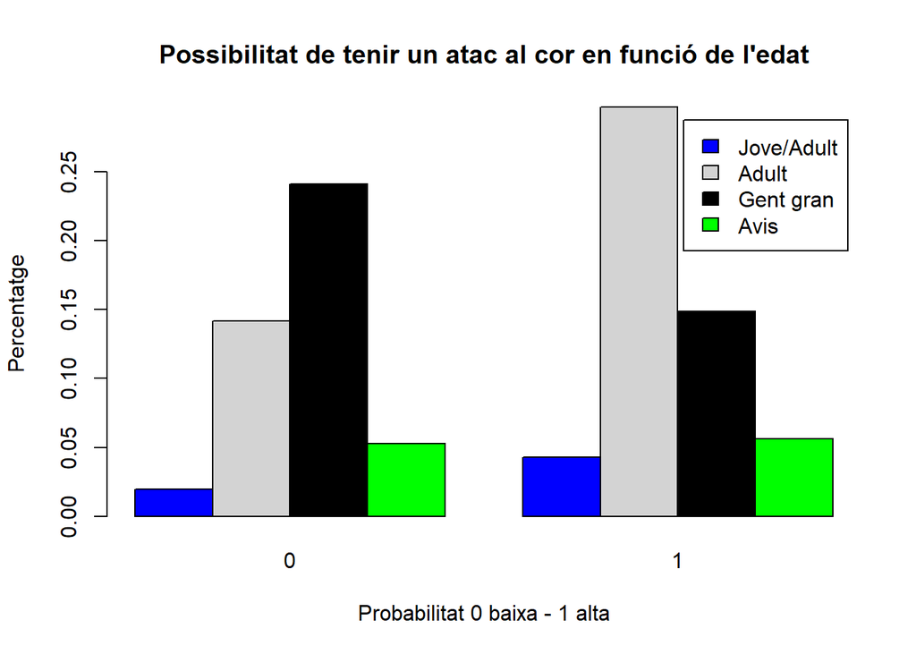

```r
counts <- table(heart_aux$segment_age, heart$output)
colors <- c("blue", "lightgrey","black","green")
barplot(prop.table(counts), beside = TRUE, col = colors,
        axes = TRUE,
        xlab = "Probabilitat 0 baixa - 1 alta",
        ylab = "Percentatge",
        main = "Possibilitat de tenir un atac al cor en funció de l'edat",
        legend = c("Jove/Adult", "Adult", "Gent gran", "Avis"))
```

Les persones Adultes que tenen entre 40 i 55 anys son les més propenses a patir un atac al cor.

## Normalitat i Homoscedasticitat.

### Normalitat

Per a cada variable continua s’aplica un test Shapiro-Wilk i s’en mostra la distribució amb un grafic de densitat per comprovar-ne la normalitat. Només la variable ‘chol’ passa el test, afortunadament sabem que gracies el teorema del limit central si el nombre d’observacions es major que 30 les variables es poden tractar coma variables amb distribució normal.

```
## [1] "Shapiro-Wilk per a la variable age"
##
##  Shapiro-Wilk normality test
##
## data:  x
## W = 0.98637, p-value = 0.005798
##
## [1] "age No segeuix una distribució normal"
## [1] "Per a la variable age la distribució dels pacients sans No segueix una distribució normal."
## [1] "Per a la variable age la distribució dels pacients malalts No segueix una distribució normal."
## [1] "Per a la variable age la distribució de les dones segueix una distribució normal."
## [1] "Per a la variable age la distribució dels homes No segueix una distribució normal."
```

```
## [1] "Shapiro-Wilk per a la variable trtbps"
##
##  Shapiro-Wilk normality test
##
## data:  x
## W = 0.98499, p-value = 0.002977
##
## [1] "trtbps No segeuix una distribució normal"
## [1] "Per a la variable trtbps la distribució dels pacients sans No segueix una distribució normal."
## [1] "Per a la variable trtbps la distribució dels pacients malalts No segueix una distribució normal."
## [1] "Per a la variable trtbps la distribució de les dones segueix una distribució normal."
## [1] "Per a la variable trtbps la distribució dels homes No segueix una distribució normal."
```

```
## [1] "Shapiro-Wilk per a la variable chol"
##
##  Shapiro-Wilk normality test
##
## data:  x
## W = 0.99371, p-value = 0.2397
##
## [1] "chol segeuix una distribució normal"
## [1] "Per a la variable chol la distribució dels pacients sans segueix una distribució normal."
## [1] "Per a la variable chol la distribució dels pacients malats segueix una distribució normal."
## [1] "Per a la variable chol la distribució de les dones segueix una distribució normal."
## [1] "Per a la variable chol la distribució dels homes segueix una distribució normal."
```

```
## [1] "Shapiro-Wilk per a la variable thalachh"
##
##  Shapiro-Wilk normality test
##
## data:  x
## W = 0.9774, p-value = 0.000103
##
## [1] "thalachh No segeuix una distribució normal"
## [1] "Per a la variable thalachh la distribució dels pacients sans segueix una distribució normal."
## [1] "Per a la variable thalachh la distribució dels pacients malats segueix una distribució normal."
## [1] "Per a la variable thalachh la distribució dels dones No segueix una distribució normal."
## [1] "Per a la variable thalachh la distribució dels homes No segueix una distribució normal."
```

```
## [1] "Shapiro-Wilk per a la variable oldpeak"
##
##  Shapiro-Wilk normality test
##
## data:  x
## W = 0.86178, p-value = 8.284e-16
##
## [1] "oldpeak No segeuix una distribució normal"
## [1] "Per a la variable oldpeak la distribució dels pacients sans No segueix una distribució normal."
## [1] "Per a la variable oldpeak la distribució dels pacients malalts No segueix una distribució normal."
## [1] "Per a la variable oldpeak la distribució dels dones No segueix una distribució normal."
## [1] "Per a la variable oldpeak la distribució dels homes No segueix una distribució normal."
```

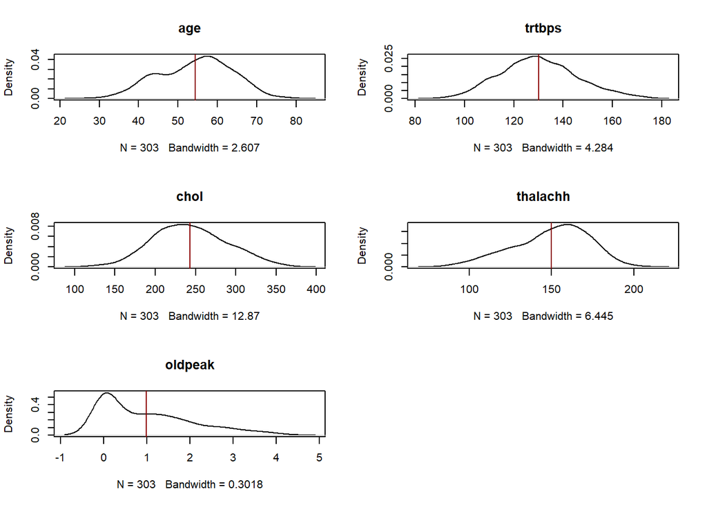

```r
par(mfrow=c(3,2))
variables <- c("age","trtbps","chol","thalachh","oldpeak")
for ( vars in variables){
  x<-heart[,vars]
  plot(density(x), main=vars )
  abline(v = mean(x), col = "darkred")
  res<- shapiro.test(x)
  print(paste("Shapiro-Wilk per a la variable",vars))
  print(res)
  if( res$p.value >0.05){
    print(paste(vars,"segeuix una distribució normal"))
  } else {
        print(paste(vars,"No segeuix una distribució normal"))
  }

  x_sa<-heart[heart$output==0,vars]
  x_malalt<-heart[heart$output==1,vars]
   if( shapiro.test(x_sa)$p.value>0.05){
    print(paste(paste("Per a la variable",vars),"la distribució dels pacients sans segueix una distribució normal."))
  } else {
     print(paste(paste("Per a la variable",vars),"la distribució dels pacients sans No segueix una distribució normal."))
  }
  if( shapiro.test(x_sa)$p.value>0.05){
    print(paste(paste("Per a la variable",vars),"la distribució dels pacients malats segueix una distribució normal."))
  } else {
     print(paste(paste("Per a la variable",vars),"la distribució dels pacients malalts No segueix una distribució normal."))
  }
  x_dona<-heart[heart$sex==0,vars]
  x_home<-heart[heart$sex==1,vars]
   if( shapiro.test(x_dona)$p.value>0.05){
    print(paste(paste("Per a la variable",vars),"la distribució de les dones segueix una distribució normal."))
  } else {
     print(paste(paste("Per a la variable",vars),"la distribució dels dones No segueix una distribució normal."))
  }
  if( shapiro.test(x_home)$p.value>0.05){
    print(paste(paste("Per a la variable",vars),"la distribució dels homes segueix una distribució normal."))
  } else {
     print(paste(paste("Per a la variable",vars),"la distribució dels homes No segueix una distribució normal."))
  }
}
```

### Homoscedasticitat

Per cada variable continua es comprova la Homoscedasticitat entre la seva distribució en relació a la probabilitat de patir un infart i al sexe.

```r
variables <- c("age","trtbps","chol","thalachh","oldpeak")
for ( vars in variables){
  x_sa<-heart[heart$output==0,vars]
  x_malalt<-heart[heart$output==1,vars]
   if( var.test(x_sa,x_malalt)$statistic==1){
    print(paste("No exisisteix diferencies entre variences respecte la probabilitat de infart per a la variable",vars))
  } else {
    print(paste("Exisisteix diferencies entre variences respecte la probabilitat de infart per a la variable",vars))
  }

  x_dona<-heart[heart$sex==0,vars]
  x_home<-heart[heart$sex==1,vars]
  if( var.test(x_dona,x_home)$statistic==1){
    print(paste("No exisisteix diferencies entre variences respecte el sexe per a la variable",vars))
  } else {
    print(paste("Exisisteix diferencies entre variences respecte el sexe per a la variable",vars))
  }
}
```

```
## [1] "Exisisteix diferencies entre variences respecte la probabilitat de infart per a la variable age"
## [1] "Exisisteix diferencies entre variences respecte el sexe per a la variable age"
## [1] "Exisisteix diferencies entre variences respecte la probabilitat de infart per a la variable trtbps"
## [1] "Exisisteix diferencies entre variences respecte el sexe per a la variable trtbps"
## [1] "Exisisteix diferencies entre variences respecte la probabilitat de infart per a la variable chol"
## [1] "Exisisteix diferencies entre variences respecte el sexe per a la variable chol"
## [1] "Exisisteix diferencies entre variences respecte la probabilitat de infart per a la variable thalachh"
## [1] "Exisisteix diferencies entre variences respecte el sexe per a la variable thalachh"
## [1] "Exisisteix diferencies entre variences respecte la probabilitat de infart per a la variable oldpeak"
## [1] "Exisisteix diferencies entre variences respecte el sexe per a la variable oldpeak"
```

## El sexe influeix en el risc de infart?.

### Hipòtesi nul·la i l’alternativa

H0 : No existeix correlacio entre les variables

H1 : Existeixen correlació entre les variables.

### Test

```r
 chisq.test(heart$sex, heart$output, correct=FALSE)
```

```
##
##  Pearson's Chi-squared test
##
## data:  heart$sex and heart$output
## X-squared = 23.914, df = 1, p-value = 1.007e-06
```

## L’edat afecta al risc de infart?.

### Hipòtesi nul·la i l’alternativa

H0 : No existeix correlacio entre les variables

H1 : Existeixen correlació entre les variables.

### Test

Apliquem Chi-square test, com que p > 0.05 acceptem la hipotesis nulla. L’edat no influeix en el risc d’infart.

```r
 chisq.test(heart$age, heart$output, correct=FALSE)
```

```
##
##  Pearson's Chi-squared test
##
## data:  heart$age and heart$output
## X-squared = 50.129, df = 40, p-value = 0.1309
```

## El colesterol en sang afecta al risc de infart?.

### Hipòtesi nul·la i l’alternativa

H0 : No existeix correlacio entre les variables

H1 : Existeixen correlació entre les variables.

### Test

Apliquem Chi-square test, com que p > 0.05 acceptem la hipotesis nulla. El colesterol en sang no influeix en el risc d’infart.

```r
 chisq.test(heart$chol, heart$output, correct=FALSE)
```

```
##
##  Pearson's Chi-squared test
##
## data:  heart$chol and heart$output
## X-squared = 170.95, df = 146, p-value = 0.07738
```

## Model de Regressió logistica

### Generació dels conjunts d’entrenament i de test

```r
set.seed(1234)
split <- sample(c(TRUE, FALSE), nrow(heart), replace=TRUE, prob=c(0.8,0.2))
train  <- heart[split, ]
test   <- heart[!split, ]
```

### Estimació del model

#### Estimació inicial

```r
model <- glm(output~age+sex+cp+trtbps+chol+fbs+restecg+thalachh+exng+oldpeak+slp+caa+thall,data=train,   family=binomial(link=logit))
summary(model)
```

```
##
## Call:
## glm(formula = output ~ age + sex + cp + trtbps + chol + fbs +
##     restecg + thalachh + exng + oldpeak + slp + caa + thall,
##     family = binomial(link = logit), data = train)
##
## Deviance Residuals:
##     Min       1Q   Median       3Q      Max
## -2.8887  -0.3495   0.1213   0.4514   2.4790
##
## Coefficients:
##              Estimate Std. Error z value Pr(>|z|)
## (Intercept)  4.938055   3.508733   1.407 0.159320
## age          0.000914   0.026889   0.034 0.972883
## sex1        -1.640559   0.605532  -2.709 0.006743 **
## cp1          1.426524   0.608042   2.346 0.018971 *
## cp2          2.306104   0.596296   3.867 0.000110 ***
## cp3          2.320979   0.749677   3.096 0.001962 **
## trtbps      -0.016383   0.014886  -1.101 0.271073
## chol        -0.011358   0.005579  -2.036 0.041776 *
## fbs1         0.612866   0.620442   0.988 0.323256
## restecg1     0.223445   0.427856   0.522 0.601501
## restecg2    -1.160596   2.569262  -0.452 0.651468
## thalachh     0.013502   0.013821   0.977 0.328611
## exng1       -1.066680   0.509039  -2.095 0.036129 *
## oldpeak     -0.213412   0.272149  -0.784 0.432938
## slp1        -0.179770   0.836466  -0.215 0.829833
## slp2         1.190436   0.908663   1.310 0.190163
## caa1        -2.422607   0.592489  -4.089 4.33e-05 ***
## caa2        -3.287934   0.868511  -3.786 0.000153 ***
## caa3        -1.587840   0.813587  -1.952 0.050979 .
## thall2      -0.426763   0.917414  -0.465 0.641802
## thall3      -2.023916   0.889231  -2.276 0.022844 *
## ---
## Signif. codes:  0 '***' 0.001 '**' 0.01 '*' 0.05 '.' 0.1 ' ' 1
##
## (Dispersion parameter for binomial family taken to be 1)
##
##     Null deviance: 344.97  on 249  degrees of freedom
## Residual deviance: 154.62  on 229  degrees of freedom
## AIC: 196.62
##
## Number of Fisher Scoring iterations: 6
```

#### Analisi de col·linealitat

Al fer un estudi de la col·linealitat, veiem que tant per la matriu de correlacions com utilitzant els coeficients VIF no existeix col·linealitat.

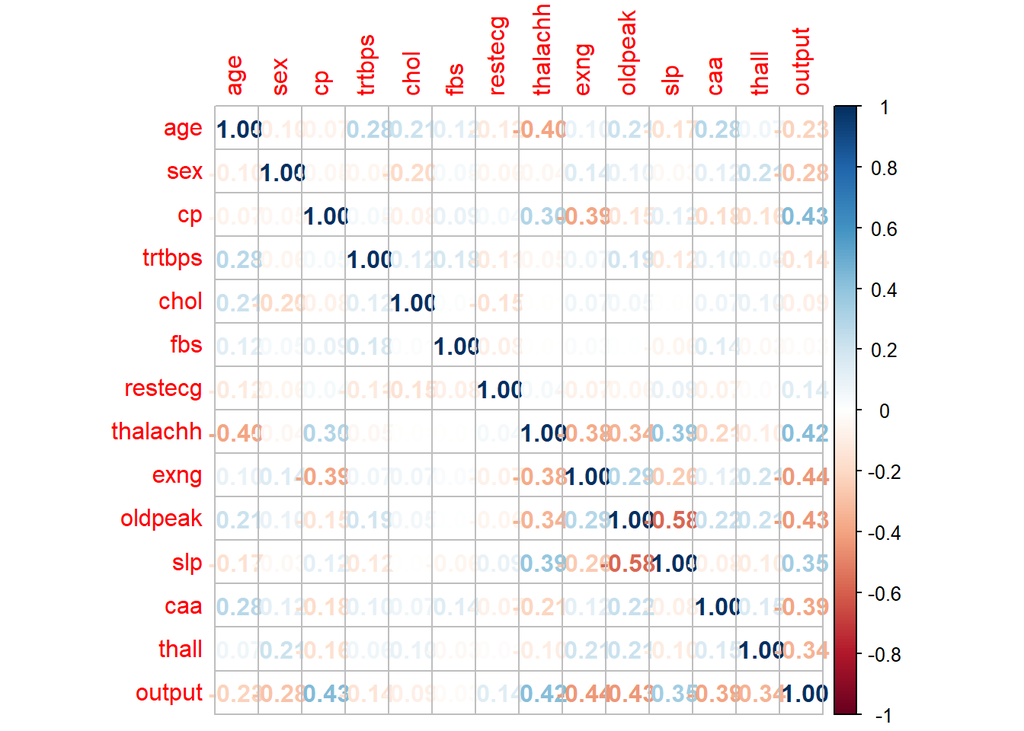

```r
corrplot(cor(heart_numeric), method = "number")
```

```r
vif(model)
```

```
##              GVIF Df GVIF^(1/(2*Df))
## age      1.408091  1        1.186630
## sex      1.624867  1        1.274703
## cp       2.029756  3        1.125228
## trtbps   1.305989  1        1.142799
## chol     1.161899  1        1.077914
## fbs      1.145959  1        1.070495
## restecg  1.162327  2        1.038322
## thalachh 1.598011  1        1.264125
## exng     1.266385  1        1.125338
## oldpeak  1.492541  1        1.221696
## slp      1.782699  2        1.155499
## caa      2.068038  3        1.128738
## thall    1.719640  2        1.145142
```

### Model final

```r
modelF <- glm(output~sex+cp+chol+thalachh+exng+slp+caa+thall,data=train,        family=binomial(link=logit))
summary(modelF)
```

```
##
## Call:
## glm(formula = output ~ sex + cp + chol + thalachh + exng + slp +
##     caa + thall, family = binomial(link = logit), data = train)
##
## Deviance Residuals:
##     Min       1Q   Median       3Q      Max
## -2.7373  -0.4114   0.1253   0.4343   2.4399
##
## Coefficients:
##               Estimate Std. Error z value Pr(>|z|)
## (Intercept)  2.4493589  2.4197780   1.012  0.31143
## sex1        -1.5068069  0.5754569  -2.618  0.00883 **
## cp1          1.5524497  0.6000346   2.587  0.00967 **
## cp2          2.3233009  0.5856190   3.967 7.27e-05 ***
## cp3          2.0364152  0.6902511   2.950  0.00318 **
## chol        -0.0118800  0.0052449  -2.265  0.02351 *
## thalachh     0.0142680  0.0126365   1.129  0.25885
## exng1       -1.0561865  0.4937803  -2.139  0.03244 *
## slp1        -0.0004576  0.7610421  -0.001  0.99952
## slp2         1.4471072  0.7926501   1.826  0.06790 .
## caa1        -2.3422115  0.5736851  -4.083 4.45e-05 ***
## caa2        -3.2417954  0.7816311  -4.147 3.36e-05 ***
## caa3        -1.6774652  0.7770182  -2.159  0.03086 *
## thall2      -0.2724351  0.9054472  -0.301  0.76350
## thall3      -1.9217124  0.8746657  -2.197  0.02801 *
## ---
## Signif. codes:  0 '***' 0.001 '**' 0.01 '*' 0.05 '.' 0.1 ' ' 1
##
## (Dispersion parameter for binomial family taken to be 1)
##
##     Null deviance: 344.97  on 249  degrees of freedom
## Residual deviance: 158.40  on 235  degrees of freedom
## AIC: 188.4
##
## Number of Fisher Scoring iterations: 6
```

#### Bondat de l’ajust mitjançant Chi-quadrat.

```r
chi2<-sum(residuals(modelF,type="pearson")^2)
d=modelF$df.null-modelF$df.residual
p=1-pchisq(chi2, df=d)

resp <-c(chi2,d,p)
names(resp)<-c("Chi-quadrat","Graus" ,"p"  )
resp
```

```
## Chi-quadrat       Graus           p
##    217.0962     14.0000      0.0000
```

```r
G <- modelF$null.deviance - modelF$deviance
G
```

```
## [1] 186.5767
```

#### Avaluació del model

```r
convert<-function (val){
  if(val >=0.5){
    return(1)
  }else{
    return(0)
  }
}
pred<-predict(modelF, newdata = test,type ="response")
predict<-lapply(pred,convert)

cf<-confusionMatrix(data=as.factor(as.numeric(predict)), reference = as.factor(test$output))
cf$table
```

```
##           Reference
## Prediction  0  1
##          0 20  5
##          1  3 25
```

```r
cf$overall["Accuracy"]
```

```
##  Accuracy
## 0.8490566
```

```r
cf$byClass["Sensitivity"]
```

```
## Sensitivity
##   0.8695652
```

```r
cf$byClass["Specificity"]
```

```
## Specificity
##   0.8333333
```

#### Corva ROC

```r
prob=predict(modelF, heart, type="response")
r=roc(heart$output, prob, data=heart)
```

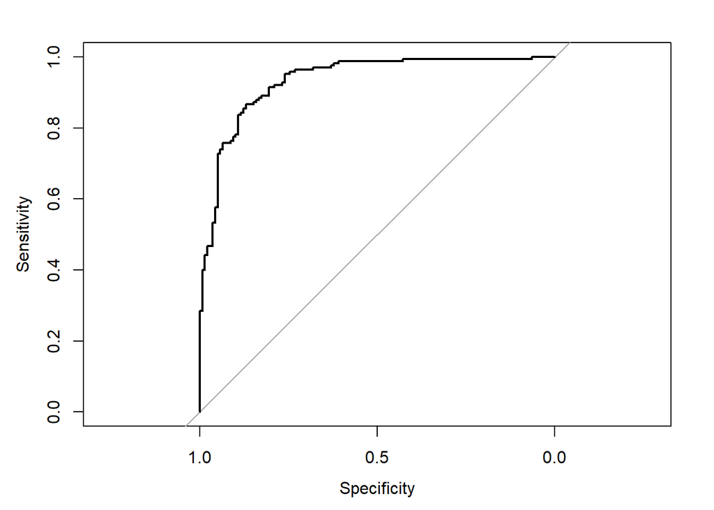

```r
plot(r)
```

```r
auc(r)
```

```
## Area under the curve: 0.9339
```

Com es pot veure, la corva ens està representant la sensibilitat en front l'especificitat del model.

Una forma de determinar com de bona és la corva ROC és atenent a l'àrea sota la corva (AUC). Normalment com més a prop de 1, més bona és, i si està per sota de 0,5 és doelnta. En el nostre cas tenim un valor AUC de **0.9339**, que determina que tenim una corva molt bona.

### Estudi del OR del model de regressió logistica

```r
exp(coefficients(modelF))
```

```
## (Intercept)        sex1         cp1         cp2         cp3        chol
## 11.58091978  0.22161649  4.72302589 10.20931838  7.66308927  0.98819030
##    thalachh       exng1        slp1        slp2        caa1        caa2
##  1.01437030  0.34777953  0.99954252  4.25080006  0.09611484  0.03909364
##        caa3      thall2      thall3
##  0.18684699  0.76152282  0.14635612
```

Dels odds-ratio de cp s’en dedueix que el dolor toràcic es el principal indicador de un alt risc de infart. Tenint els pacients amb una angina atípica 10 vegades la probabilitat d’ocurrencia d’un risc alt de infart, els pacients amb una angina típica 4.7 vegades i els pacients amb un dolor agngios 7.7 vegades més probabilitats que la resta de pacients.

Aixi mateix, el pendent del segment ST és també un bon indicador de la probabilitat de ocurrencia de un risc alt de infart, sent els pacients amb un pendent negatiu 4.2 vegades més propensos a tenir un risc alt de infart.

Per altra banda es pot veure que com a principals factors protectors contre risc de infart trobem els vasos afectats, i el sexe on, per exemple, l’odds-ratio estimat per a sex=1 és 0.22, de manera que l’ocurrència de un risc alt de infart és 0,22 vegades menor, en relació al sexe=0.

### Visualitzacio del model

Finalment visualitzem el model de regressió. On es pot veure com afecten cada una de les variables al risc de infart. Sent aquelles variables a la esquerra de la grafica del model variables protectores i aquelles variables a la dreta factors de risc de cara a patir un infart. Així mateix aquelles variables que cauen a la zona gris central no tenen afectació real en la probabiltat de risc de infart.

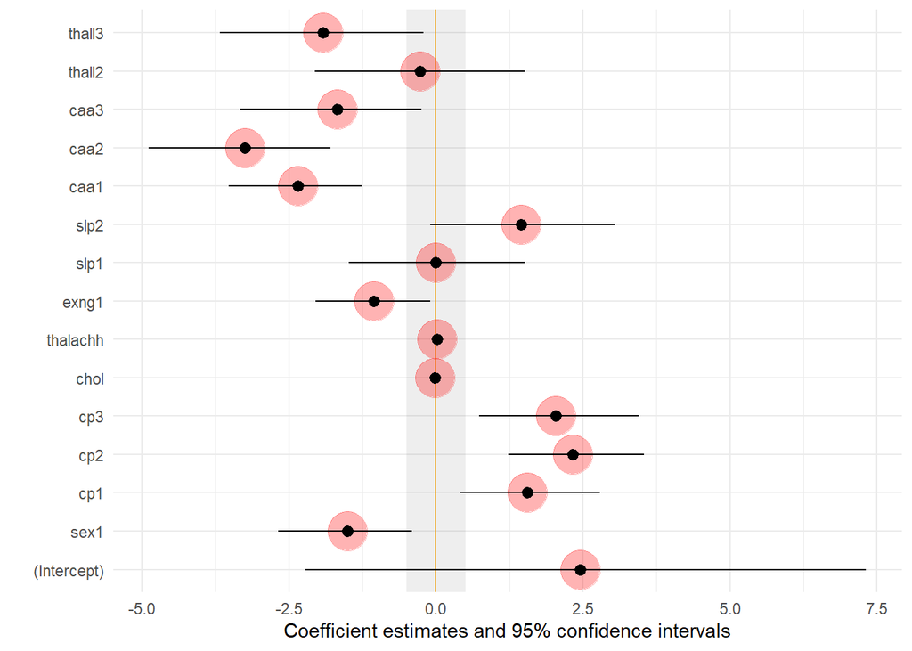

```r
b <- list(geom_vline(xintercept = 0, color = 'orange'),
          annotate("rect", alpha = .1,
                   xmin = -.5, xmax = .5,
                   ymin = -Inf, ymax = Inf),
          geom_point(aes(y = term, x = estimate), alpha = .3,
                     size = 10, color = 'red'))

modelplot(modelF , background = b)
```